# pset_salvin

## Problem 1: Logistic Regression Decision Boundaries

This problem asks you to find the decision boundary equations (where P(y=1) = 0.5) for several logistic regression models by setting the linear part inside the exponential equal to zero. Then, we rearrnage the plot these boundaries using `NumPy` and `Matplotlib` to visualize how the model separates the classes.

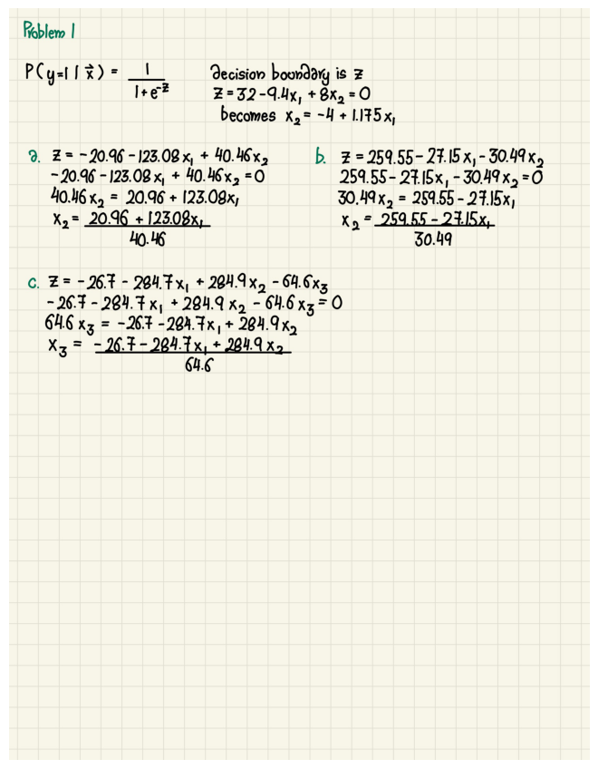

```python
# importing libraries
import matplotlib.pyplot as plt
import matplotlib.image as mpimg

# load the image
img = mpimg.imread('C:/GitHub/Semester 5/TheoryOfMachineLearning/7_week-seven/pset/images/one.jpg')

# display the image
plt.figure(figsize=(8.27, 11.69))
plt.imshow(img)
plt.axis('off')
plt.show()
```

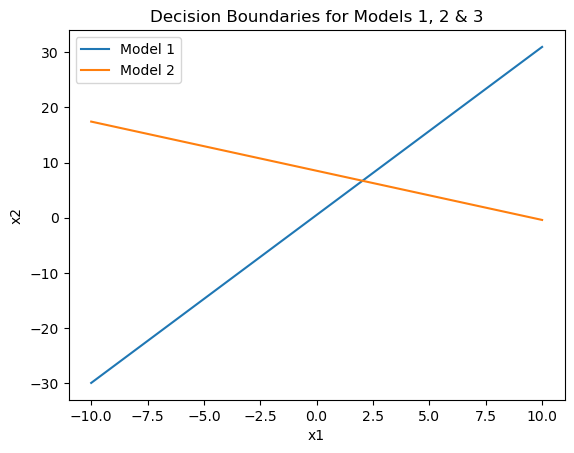

```python
"""
    find the equation of the line/plane for each fitted model below and plot the line/plane

    - $P(y = 1 | x) = \frac{1}{1+e^{-(-20.96-123.08x_1+40.46x_2)}}$
    - $P(y = 1 | x) = \frac{1}{1+e^{-(259.55-27.15x_1-30.49x_2)}}$
"""

# importing libraries
import numpy as np

# x1 and x2 values for model 1
model_one_x1 = np.linspace(-10, 10, 100)
model_one_x2 = (20.96 + 123.08 * model_one_x1) / 40.46

# x1 and x2 values for model 2
model_two_x1 = np.linspace(-10, 10, 100)
model_two_x2 = (259.55 - 27.15 * model_two_x1) / 30.49

# plotting code for model 1 and model 2
plt.plot(model_one_x1, model_one_x2, label='Model 1')
plt.plot(model_two_x1, model_two_x2, label='Model 2')
plt.xlabel("x1")
plt.ylabel("x2")
plt.title("Decision Boundaries for Models 1, 2 & 3")
plt.legend()
plt.show()
```

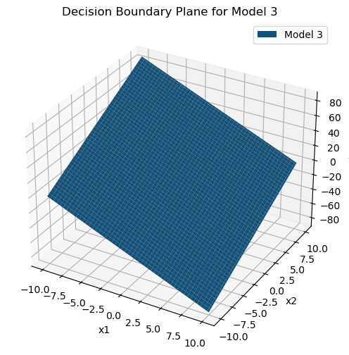

```python
"""
    find the equation of the line/plane for each fitted model below and plot the line/plane

    - $P(y = 1 | x) = \frac{1}{1+e^{-(-26.7-284.7x_1+284.9x_2-64.6x_3)}}$
"""

# x1, x2 and x3 values for model 3
x1 = np.linspace(-10, 10, 100)
x2 = np.linspace(-10, 10, 100)
x1, x2 = np.meshgrid(x1, x2)
x3 = (-26.7 - 284.7 * x1 + 284.9 * x2) / 64.6


# plotting code
fig = plt.figure(figsize=(8, 6))
ax = fig.add_subplot(111, projection='3d')
ax.plot_surface(x1, x2, x3, label="Model 3")
ax.set_xlabel("x1")
ax.set_ylabel("x2")
ax.set_zlabel("x3")
ax.set_title("Decision Boundary Plane for Model 3")
plt.legend()
plt.show()
```

## Problem 2: Log-liklihoood

In this problem, we compute the per-sample and overall likelihoods for a logistic regression model using the logistic regression likelihood formula, showing how well the model's predicted probabilities match the true labels.

- The best likelihood happens when all predictions perfectly match the true classes
- The worst likelihood happens when all predictions are completely opposite

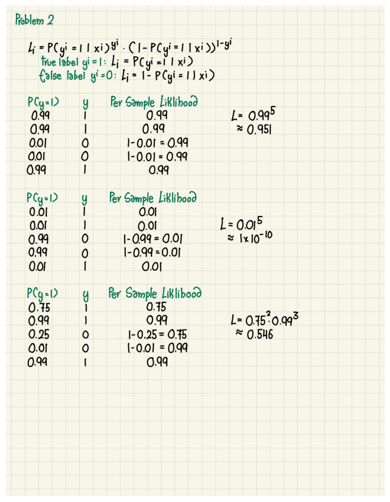

```python
# load the image
img = mpimg.imread('C:/GitHub/Semester 5/TheoryOfMachineLearning/7_week-seven/pset/images/two.jpg')

# display the image
plt.figure(figsize=(8.27, 11.69))
plt.imshow(img)
plt.axis('off')
plt.show()
```

As from the calculations above, we can see that the best likelihood is 0.99^5 and the worst likelihood is 1 × 10^-10.

## Problem 3: Interpretability of Logistic Regression

In this problem, we look at the interpretability of linear and logistic regression models. These models explain how linear regression weights inddicate the change in the predicted outcome per unit change in a feature and for logistic regression, the weights describe how the odds of of the tarrget class change with each feature.

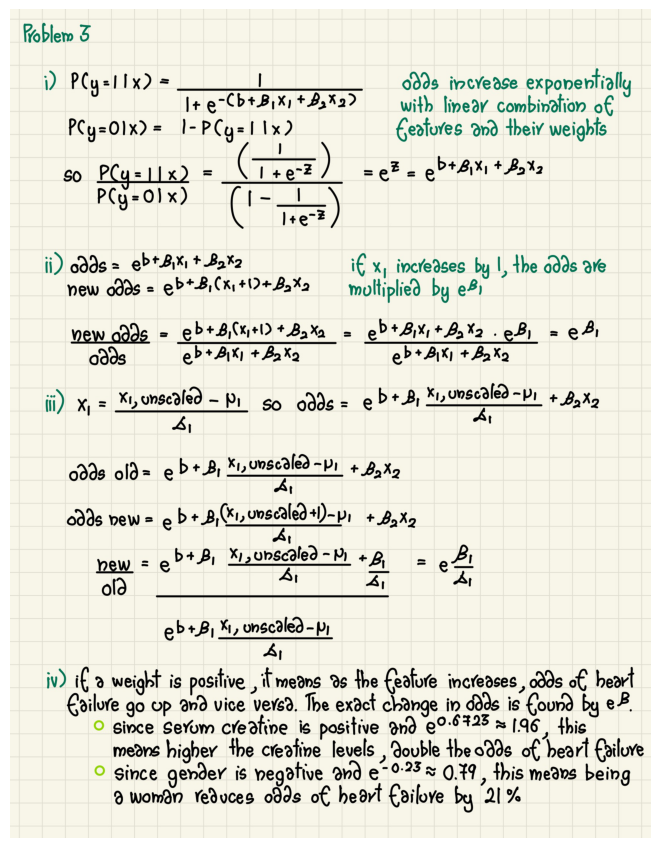

```python
# load the image
img = mpimg.imread('C:/GitHub/Semester 5/TheoryOfMachineLearning/7_week-seven/pset/images/three.jpg')

# display the image
plt.figure(figsize=(8.27, 11.69))
plt.imshow(img)
plt.axis('off')
plt.show()
```

## Problem 4: Growing Trees & Gini Index

In this problem, we explore how decision trees use the Gini index to measure impurity and choose the best feature and threshold for splitting data during tree construction (using CART algorithm). You'll calculate Gini indices for different cases, evaluate possible splits for two features in a small dataset and determine which feature forms the best root node based on the lowest impurtiy.

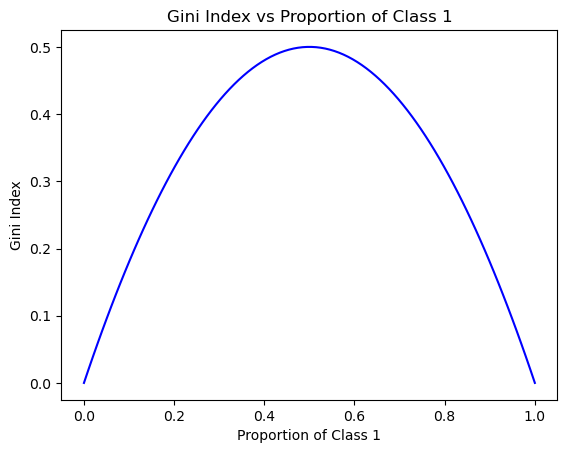

```python
"""
    1b. plot the function of Gini index with respect to prop(of class 1)
"""

def gini(prop1):
    return 2 * prop1 * (1 - prop1)

# calculating gini values
prop1 = np.linspace(0, 1, 100)
gini_values = gini(prop1)

# plotting code
plt.plot(prop1, gini_values, color='blue')
plt.title('Gini Index vs Proportion of Class 1')
plt.xlabel('Proportion of Class 1')
plt.ylabel('Gini Index')
plt.show()
```

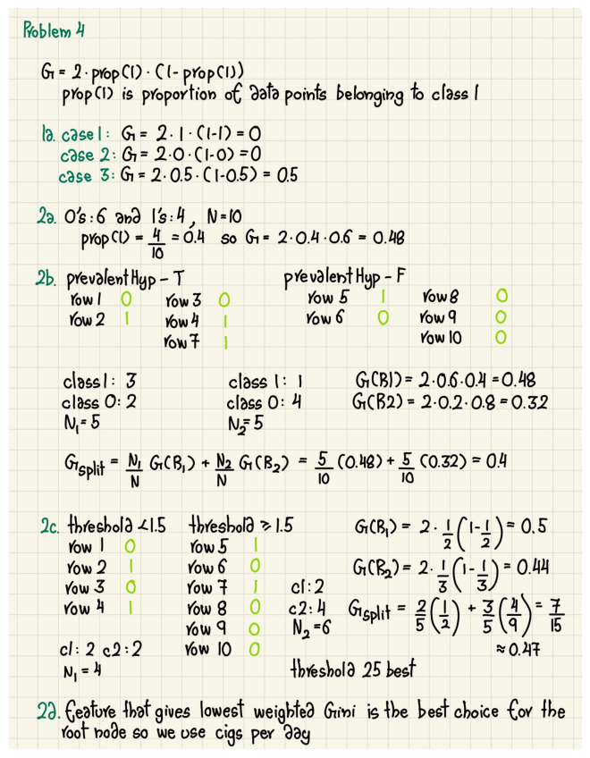

```python
# load the image
img = mpimg.imread('C:/GitHub/Semester 5/TheoryOfMachineLearning/7_week-seven/pset/images/four.jpg')

# display the image
plt.figure(figsize=(8.27, 11.69))
plt.imshow(img)
plt.axis('off')
plt.show()
```

## Problem 5: Given Trees

In this last problem, we visualize how different feature pairs separate wine classes, analyze and trace decision tree predictions for given samples and interpret tree structure and decision boundaries. We also explore differences in tree complexities and compare how decision trees handle multi-class problems against logistic regression.

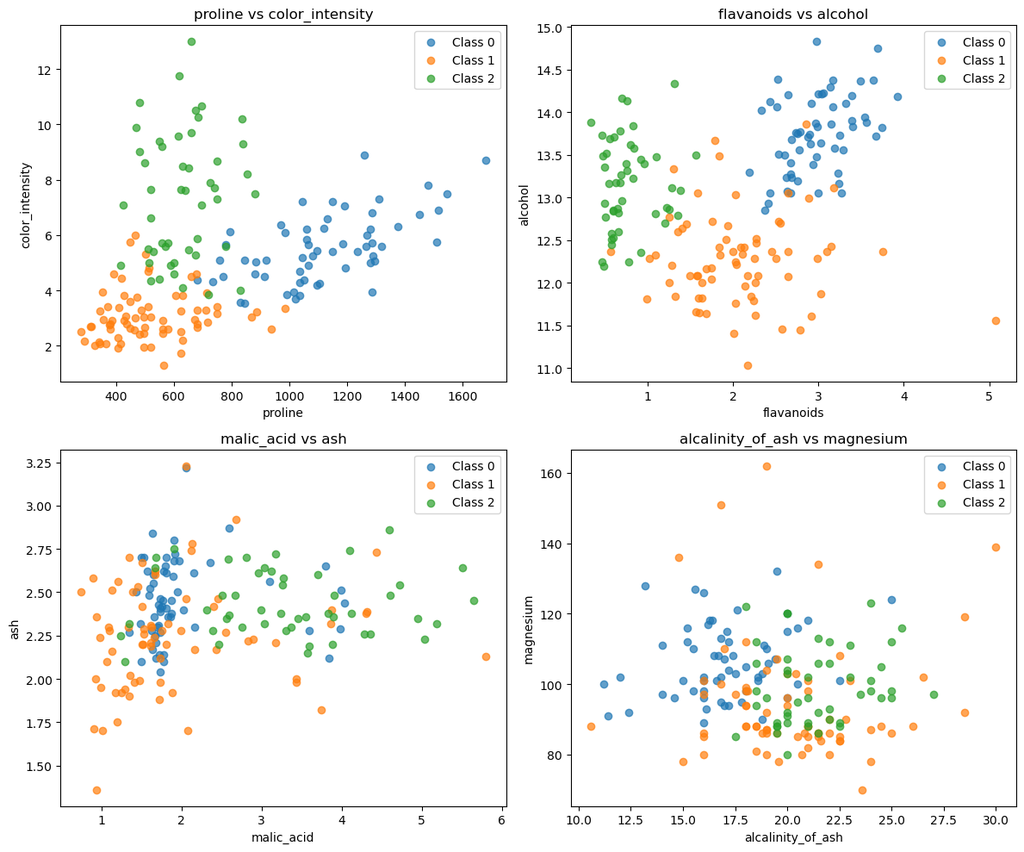

```python
"""
    create scatter plots using the proline and color intensity, flavanoids and alcohol, malic_acid and ash, and alcalinity_of_ash and
    magnesium feature pairs. The points should be colored by class.

"""


# required imports
from sklearn.datasets import load_wine
import pandas as pd

# the wine dataset
wine = load_wine()
X = pd.DataFrame(wine.data, columns=wine.feature_names)
y = wine.target

# the feature pairs
feature_pairs = [
    ('proline', 'color_intensity'),
    ('flavanoids', 'alcohol'),
    ('malic_acid', 'ash'),
    ('alcalinity_of_ash', 'magnesium')
]

# plotting code
fig, axes = plt.subplots(2, 2, figsize=(12, 10))

for ax, (f1, f2) in zip(axes.flatten(), feature_pairs):
    for class_value in range(3):
        ax.scatter(
            X[f1][y == class_value],
            X[f2][y == class_value],
            label=f'Class {class_value}',
            alpha=0.7
        )
    ax.set_xlabel(f1)
    ax.set_ylabel(f2)
    ax.set_title(f'{f1} vs {f2}')
    ax.legend()

plt.tight_layout()
plt.show()
```

**Question 5b:** Create a table with 4 rows and 2 columns. List the features used in each plot in one column and whether the classes can be easily separated using the features in that plot.

| Feature Pair | Class Separation |
| --- | --- |
| proline & color_intensity | Classes are well separated |
| flavanoids & alcohol | Classes are well separated but with slight overlap |
| malic_acid & ash | The classes overlap a lot |
| alcalinity_of_ash & magnesium | The classes overlap a lot |

**Question 5c:** Trace DT 1 to classify the folloqing samples below:

| Alcohol | Color Intensity | Flavanoids | Proline | Predicted Class |
| --- | --- | --- | --- | --- |
| 0.5 | 5 | 1 | 500 | 2 |
| 0.75 | 4.25 | 0.75 | 525 | 2 |
| 0 | 4 | 3 | 800 | 0 |

**Question 5d:** For samples in (c), trace the path from the root to the leaf and provide the corresponding Boolean expression.

**Question 5e:** On the proline and color intensity and flavanoids and alcohol feature pair scatter plots from (a), plot the decision lines for every non-leaf node of the tree.

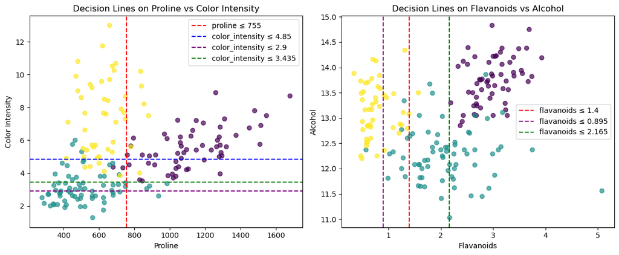

```python
"""
    plot proline vs color intensity AND flavanoids va alcohol

"""

data = load_wine()
X = data.data
y = data.target
feature_names = data.feature_names

# columns for plotting
proline = X[:, feature_names.index('proline')]
color_intensity = X[:, feature_names.index('color_intensity')]
flavanoids = X[:, feature_names.index('flavanoids')]
alcohol = X[:, feature_names.index('alcohol')]

fig, axes = plt.subplots(1, 2, figsize=(12, 5))

# proline vs color intensity
axes[0].scatter(proline, color_intensity, c=y, cmap='viridis', alpha=0.7)
axes[0].set_xlabel('Proline')
axes[0].set_ylabel('Color Intensity')
axes[0].set_title('Decision Lines on Proline vs Color Intensity')

axes[0].axvline(x=755, color='red', linestyle='--', label='proline ≤ 755')
axes[0].axhline(y=4.85, color='blue', linestyle='--', label='color_intensity ≤ 4.85')
axes[0].axhline(y=2.9, color='purple', linestyle='--', label='color_intensity ≤ 2.9')
axes[0].axhline(y=3.435, color='green', linestyle='--', label='color_intensity ≤ 3.435')
axes[0].legend()

# flavanoids va alcohol
axes[1].scatter(flavanoids, alcohol, c=y, cmap='viridis', alpha=0.7)
axes[1].set_xlabel('Flavanoids')
axes[1].set_ylabel('Alcohol')
axes[1].set_title('Decision Lines on Flavanoids vs Alcohol')

axes[1].axvline(x=1.4, color='red', linestyle='--', label='flavanoids ≤ 1.4')
axes[1].axvline(x=0.895, color='purple', linestyle='--', label='flavanoids ≤ 0.895')
axes[1].axvline(x=2.165, color='green', linestyle='--', label='flavanoids ≤ 2.165')
axes[1].legend()

# plotting the plots
plt.tight_layout()
plt.show()
```

**Question 5f:** The two trees are of very different sizes. Why do you think that is?

This is because the features such as proline, color intensity, flavanoids and alcohol are highly informative features, which means they're features that separate the wine classes very clearly. As a result, this leads to a smaller tree because fewer decisions are needed. The second decision tree would is deeper and more complex because the features cause the classes to overlap and as a result the tree needs more splits to separate the classes accurately. As a result, we have a much larger tree because we need to go through more decisions to find the boundaries that separate the classes well.

**Question 5g:** For logistic regression, we need to use a one-versus-all scheme with multiple models to handle multi-class problems. How are multi-class problems handled with decision trees?

When we use logistic regression, we are using a binary model that models the porbability of one class against all other classes. So, to handle multi-class problems, we need to train multiple models. Decision trees on the other hand can handle multi-class classification, which means there is no need to train multiple models. It is at each split that the tree chooses the feature and threshold that best reduces impurity across all classes, using metric such as the Gini impurity. As a result, each node split is chosen to best separate all classes simultaneously based on impurity reduction.